# Car Selling Price

Mon Oct-07-2019

## Background

The goal of this analysis is to provide an estimate of the “cost per mile” of a vehicle. The vehicle will be a *1995 Ford Thunderbird with 170,000 miles which cost me $1,200*.

Because a car always has value/price and this price is never below $0, a linear model will not be the best method to use for this analysis. We’ll be transforming our data so the model fits the data.

For this analysis, we’ll plan to sell it after 12,000 more miles (so about a year from now, when the car will have 182,000 miles) and see whether I’ll make some profit from this or not.

## Data

```r
datatable(price_mileage)
```

|  | Mileage | Price |
| --- | --- | --- |
| 1 | 189000 | 1995 |
| 2 | 340000 | 2000 |
| 3 | 70675 | 7500 |
| 4 | 100000 | 2400 |
| 5 | 119500 | 3500 |
| 6 | 20000 | 26500 |
| 7 | 62000 | 10995 |
| 8 | 59953 | 15979 |
| 9 | 73000 | 11000 |
| 10 | 122548 | 6995 |

[output cut: 27 more lines]

You can find the website from where we collected the data [here](https://cars.ksl.com/search/index?make%5B%5D=Ford&model%5B%5D=Thunderbird&yearFrom=1900&yearTo=2020&mileageTo=1000000).

## Analysis

#### First linear model

First, we’ll perform a *simple linear regression* analysis for Price and Mileage of our Ford Thunderbird.

$$\underbrace{Y_i}_\text{Price} = \beta_0 +\beta_1 \underbrace{X_i}_\text{Mileage} + \epsilon_i \quad \text{where} \ \epsilon_i \sim N(0,\sigma^2)$$
The null hypothesis is that there is no correlation between the mileage and the price of a car. The alternative hypothesis is that there is a non-zero slope representing that correlation. The significance level will be at 0.05.

$$H_0: \beta_1 = 0$$
$$H_a: \beta_1 \neq 0$$
$$\alpha = 0.05$$

When we run the summary of the linear model we can get important values such as R-squared (let’s remember that a value of 1 means our model explains 100% of the variablity in the data).

```r
ford.lm <- lm(Price ~ Mileage, data = price_mileage)
predicted <- predict(ford.lm, data.frame(Mileage = 182000))
original_info <- c(170000,1200)
pander(summary(ford.lm))
```

|  | Estimate | Std. Error | t value | Pr(>\|t\|) |
| --- | --- | --- | --- | --- |
| **(Intercept)** | 18299 | 2669 | 6.856 | 5.869e-08 |
| **Mileage** | -0.072 | 0.02204 | -3.266 | 0.002441 |

Fitting linear model: Price ~ Mileage

| Observations | Residual Std. Error | $R^2$ | Adjusted $R^2$ |
| --- | --- | --- | --- |
| 37 | 9687 | 0.2336 | 0.2117 |

This can be better displayed in a graph:

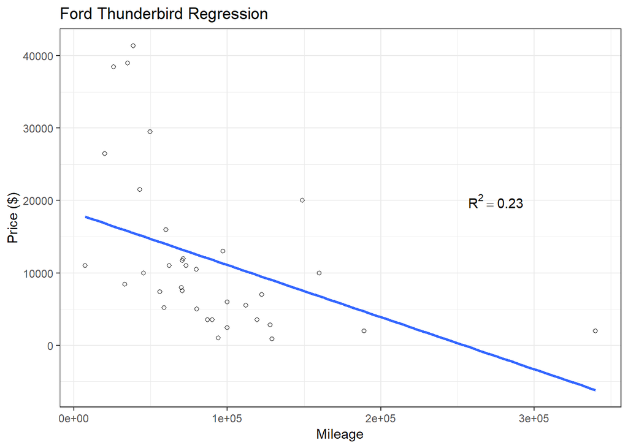

```r
ggplot(price_mileage, aes(x=Mileage, y=Price)) +
  geom_point(shape = 1) +
  geom_smooth(method = lm, se = FALSE) +
  scale_x_continuous(name = 'Mileage') +
  scale_y_continuous(name = 'Price ($)') +
  ggtitle('Ford Thunderbird Regression') +
  theme_bw() +
  annotate("text", x=275000, y=20000, label = "R^2 == 0.23", parse=T)
```

As displayed in the summary of our linear model, the p-value of both slope and intercept are significant (0.002441 and 5.869e-08 respectively). Thus, there is enough evidence to reject the null hypothesis and conclude that the average price of a Thunderbird is predictable using its mileage (slope is significant).

However, the $R^2$ is only 0.2336 which is not really good.

To see if our conclusions are valid, we have to run some diagnostic plots.

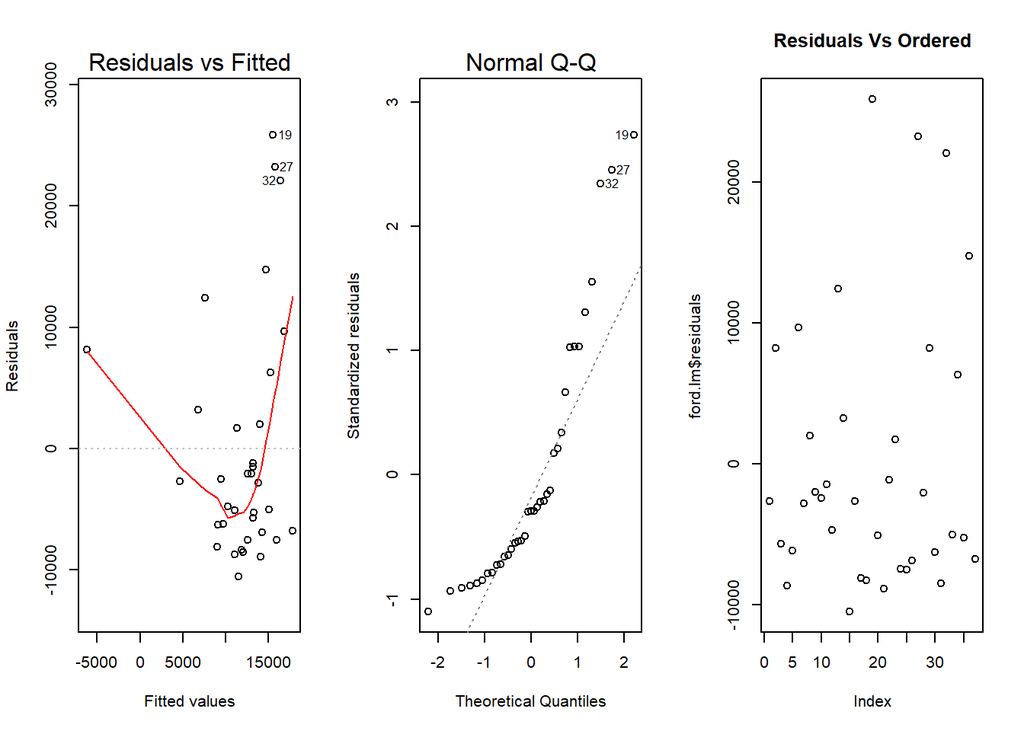

```r
par(mfrow = c(1,3))
plot(ford.lm, which = 1)
plot(ford.lm, which = 2)
plot(ford.lm$residuals, main = "Residuals Vs Ordered")
```

The residuals are not normally distributed (normall Q-Q plot) and there’s no linearity in the data (Residuals vs Fitted). The results of this predictive model are not to be trusted.

In the next section, we will try to find a transformation of our data that will give us a more fitting predictive model.

#### Second linear model (transformation of Y)

To know which type of transformation works best for our data, we will use the boxCox function:

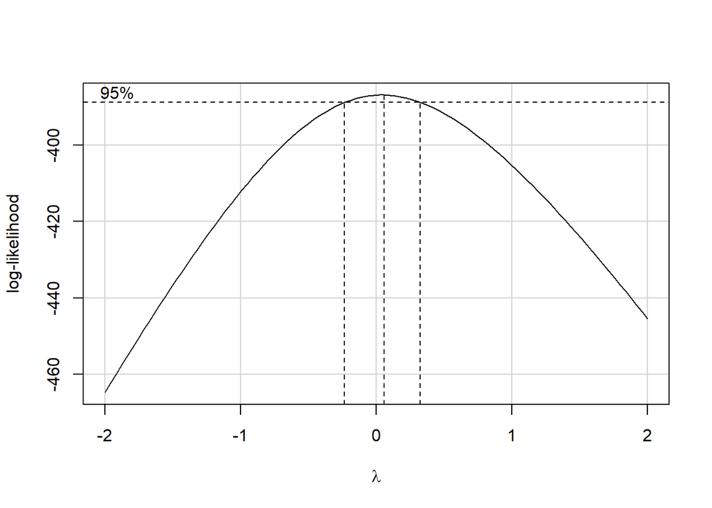

```r
boxCox(ford.lm)
```

The graph suggests to use $\lambda = 0$, which means the transformation we should apply is $log(Y)$.

So our equations end up being transformed like this:

$$Y'_i = log(Y_i)$$
$$Y'_i = \beta_0 + \beta_1 X_i + \epsilon_i$$
$$Y_i = exp(Y'_i) = exp(\beta_0 + \beta_1 X_i + \epsilon_i)$$
The null and alternative hypothesis, as well as our level of significance will be the same we used in our first model.

After applying the transformation, we get the following results:

```r
lambda0 <- lm(log(Price) ~ Mileage, data = price_mileage)

pander(summary(lambda0))
```

|  | Estimate | Std. Error | t value | Pr(>\|t\|) |
| --- | --- | --- | --- | --- |
| **(Intercept)** | 9.687 | 0.2232 | 43.39 | 5.038e-32 |
| **Mileage** | -8.172e-06 | 1.844e-06 | -4.433 | 8.78e-05 |

Fitting linear model: log(Price) ~ Mileage

| Observations | Residual Std. Error | $R^2$ | Adjusted $R^2$ |
| --- | --- | --- | --- |
| 37 | 0.8101 | 0.3595 | 0.3412 |

Like in our first model, both p-values are under 0.05 – they are significant. However, with an $R^2=0.3412$, we see a slight increase in goodness of fit.

Again, to see if our conclusions are valid, we have to run some diagnostic plots.

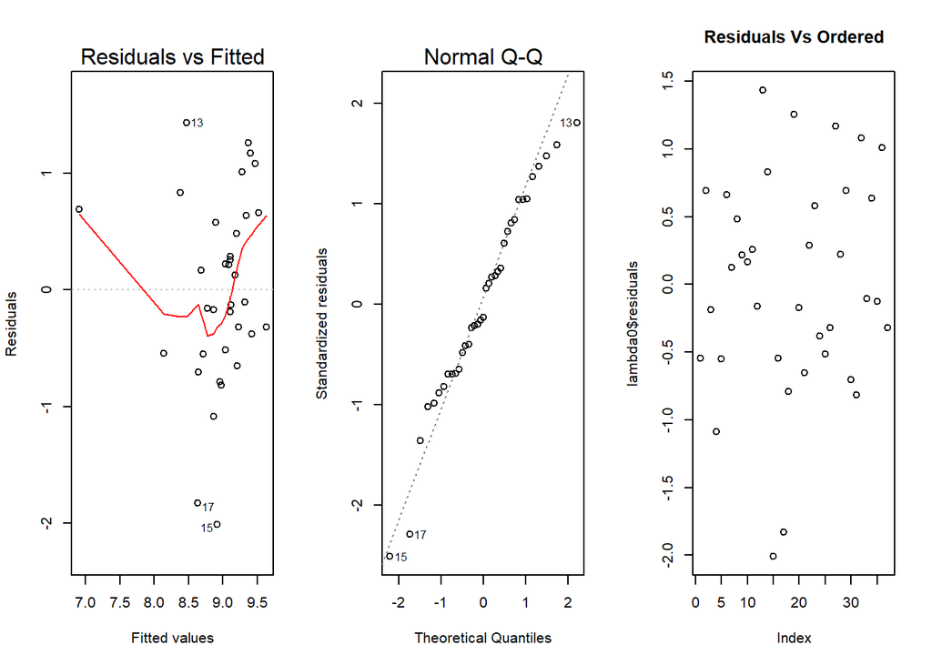

```r
par(mfrow = c(1,3))
plot(lambda0, which = 1)
plot(lambda0, which = 2)
plot(lambda0$residuals, main = "Residuals Vs Ordered")
```

The residuals are now normally distributed (normall Q-Q plot) and we see linearity in the data (no pattern in the Residuals vs Fitted graph). Compared to our first model, the results of this predictive model can be trusted, but because our $R^2$ is still small, I’d would not trust the predictions.

Our transformation can be seen in the following graph:

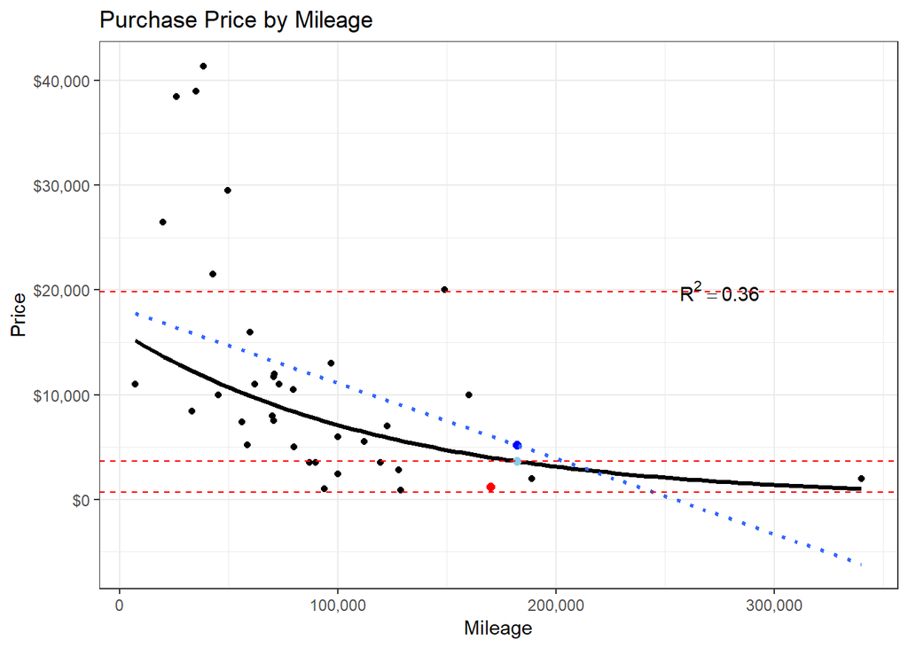

```r
predicted2 <- exp(predict(lambda0, data.frame(Mileage = 182000)))
preds <- exp(predict(lambda0, data.frame(Mileage = 182000), interval = "prediction"))
price_mileage %>%
  ggplot(aes(x = Mileage, y = Price)) +
  geom_point() +
    stat_function(fun=function(x) exp(coef(lambda0)[1] + coef(lambda0)[2] * x), geom="line",size = 1.2) +
  geom_point(aes(x = 182000,y =  predicted), color = "blue", size = 2) +
  geom_point(aes(x = original_info[1], y = original_info[2]), color = "red", size = 2) +
  labs(title = "Purchase Price by Mileage") +
  scale_y_continuous(labels = scales::dollar) +
  scale_x_continuous(labels = scales::comma) +
  theme_bw() +
  geom_smooth(method = "lm", se = F, linetype = "dotted", alpha = .2) +
  annotate("text", x = 275000, y = 20000, label = "R^2 == 0.36", parse = T)  +
  geom_point(aes(x = 182000,y =  predicted2), color = "skyblue", size = 2) + geom_hline(yintercept = preds[1], linetype="dashed", color = "red") + geom_hline(yintercept = preds[2], linetype="dashed", color = "red") + geom_hline(yintercept = preds[3], linetype="dashed", color = "red")
```

The red dot is the price of our car when we bought it with 170,000 miles. The blue dot is our predicted price if we sold the car in a year (182,000 miles) using the first model, and the skyblue one is using our second model.